# Homework 10

Manali Rege-Colt

4/21/2021

## For Loops and Randomization Tests

1. Use a for loop to write a function that calculates the number of zeros in a numeric vector. Before entering the loop, set up a counter variable counter <- 0. Inside the loop, add 1 to counter each time you have a zero in the matrix. Finally, use return(counter) for the output.

```r
# ----------------------------------------
# FUNCTION zero_count
# description: calculates the number of zeroes in a numeric vector
# inputs: a vector of numerics
# outputs: the number of zeroes in the vector
###########################################
zero_count <- function(x=my_vec) {
  counter <- 0
  for (i in seq_along(my_vec)) {
    if(my_vec[i]==0) {
      counter <- counter + 1
    }
  }
 return(counter)
  } # end of zero_count
#-------------------------------------------
my_vec <- c(rep(0,10),4,6,3,8,8,2)
zero_count(my_vec)
```

```
## [1] 10
```

2. Use subsetting instead of a loop to rewrite the function as a single line of code.

```r
subset_vec <- c(rep(0,10),6,3,8,8,2)
subset_counter <- length(subset_vec[subset_vec==0])
subset_counter
```

```
## [1] 10
```

3. Write a function that takes as input two integers representing the number of rows and columns in a matrix.

```r
# ----------------------------------------
# FUNCTION set_matrix
# description: creates a matrix where each value is the product of the row number and column number
# inputs: integer for the rows, integer for the columns
# outputs: matrix with dimensions where each element is the product of the row and column integer numbers
###########################################
set_matrix <- function(r=5,c=5) {
  my_matrix <- matrix(NA,nrow=r,ncol=c)
  for (i in 1:nrow(my_matrix)) {
    for (j in 1:ncol(my_matrix)) {
      my_matrix[i,j] <- i*j
    }
  }
  return(my_matrix)
  }# end of set_matrix
#-------------------------------------------

set_matrix()
```

```
##      [,1] [,2] [,3] [,4] [,5]
## [1,]    1    2    3    4    5
## [2,]    2    4    6    8   10
## [3,]    3    6    9   12   15
## [4,]    4    8   12   16   20
## [5,]    5   10   15   20   25
```

4. Use the code from the April 8th lecture (Randomization Tests) to design and conduct a randomization test for some of your own data.

```r
# Preliminaries------------------------------
library(ggplot2)
library(TeachingDemos)
library(tidyverse)
set.seed(100)

# create treatment groups
trt_group <- c(rep("BoatAbsent",4),rep("BoatPresent",5))
print(trt_group)
```

```
## [1] "BoatAbsent"  "BoatAbsent"  "BoatAbsent"  "BoatAbsent"  "BoatPresent"
## [6] "BoatPresent" "BoatPresent" "BoatPresent" "BoatPresent"
```

```r
# create response variable
z <- c(runif(4) + 1, runif(5) + 10)
print(z)
```

```
## [1]  1.307766  1.257673  1.552322  1.056383 10.468549 10.483771 10.812403
## [8] 10.370321 10.546559
```

```r
# combine into data frame
df <- data.frame(trt=trt_group,res=z)
print(df)
```

```
##           trt       res
## 1  BoatAbsent  1.307766
## 2  BoatAbsent  1.257673
## 3  BoatAbsent  1.552322
## 4  BoatAbsent  1.056383
## 5 BoatPresent 10.468549
## 6 BoatPresent 10.483771
## 7 BoatPresent 10.812403
## 8 BoatPresent 10.370321
## 9 BoatPresent 10.546559
```

```r
# look at means in observed data
obs <- tapply(df$res,df$trt,mean)
print(obs)
```

```
##  BoatAbsent BoatPresent
##    1.293536   10.536320
```

```r
# create a simulated data set

# set up a new data frame
df_sim <- df

# randomize assignment of response to treatment groups
df_sim$res <- sample(df_sim$res)
print(df_sim)
```

```
##           trt       res
## 1  BoatAbsent 10.812403
## 2  BoatAbsent 10.370321
## 3  BoatAbsent 10.483771
## 4  BoatAbsent 10.546559
## 5 BoatPresent  1.056383
## 6 BoatPresent  1.552322
## 7 BoatPresent  1.257673
## 8 BoatPresent 10.468549
## 9 BoatPresent  1.307766
```

```r
#look at means in simulated data
sim <- tapply(df_sim$res,df$trt,mean)
print(sim)
```

```
##  BoatAbsent BoatPresent
##   10.553263    3.128539
```

```r
# Build Functions ------------------------------

####### ###########################################
# function: readData
# read in (or generate) data set for analysis
# input: file name (or nothing, for this demo)
# output: 3 column data frame of observed data (ID,x,y)
#-------------------------------------------------
readData <- function(z=NULL) {
                if(is.null(z)){
                  boatPres <- 1:20
                  freqMod <- boatPres + 10*rnorm(20)
                  dF <- data.frame(ID=seq_along(boatPres),
                                   boatPres,
                                   freqMod)} # set up data frame
#  dF <-read.table(file=z,row.names=1,header=TRUE,sep=",",stringsAsFactors=FALSE)
# print(qplot(x=xObs,y=yObs)) # peek at input data
return(dF)
}# end of readData
# --------------------------------------------------

readData()
```

```
##    ID boatPres    freqMod
## 1   1        1 -2.5986213
## 2   2        2  2.8988614
## 3   3        3  3.9627446
## 4   4        4  1.9836605
## 5   5        5 12.3984050
## 6   6        6  7.2337950
## 7   7        7  6.7068329
## 8   8        8  4.1114575
## 9   9        9 14.1085626
## 10 10       10  0.8618581
## 11 11       11 34.1029682
## 12 12       12  7.6191002
## 13 13       13 20.6406062
## 14 14       14 16.6196129
## 15 15       15 22.7340460
## 16 16       16  7.8562088
## 17 17       17 12.6154943
## 18 18       18 10.7977845
## 19 19       19 21.3094453
## 20 20       20  8.4227054
```

```r
# Calculate Metric ------------------------------

##################################################
# function: getMetric
# calculate metric for randomization test
# input: 2-column data frame for regression
# output: regression slope
#-------------------------------------------------
getMetric <- function(z=NULL) {
                if(is.null(z)){
                  boatPres <- 1:20
                  freqMod <-  boatPres + 10*rnorm(20)
                  z <- data.frame(ID=seq_along(boatPres),
                                  boatPres,
                                  freqMod)} # set up data frame

. <- lm(z[,3]~z[,2])
. <- summary(.)
. <- .$coefficients[2,1]

slope <- .

return(slope)

} # end of getMetric
#--------------------------------------------
getMetric()
```

```
## [1] 1.061194
```

```r
# Create Randomization ------------------------------

##################################################
# function: shuffleData
# randomize data for regression analysis
# input: 3-column data frame (ID,xVar,yVar)
# output: 3-column data frame (ID,xVar,yVar)
#-------------------------------------------------
shuffleData <- function(z=NULL) {
                if(is.null(z)){
                  boatPres <- 1:20
                  freqMod <- boatPres + 3*rnorm(20)
                  z <- data.frame(ID=seq_along(boatPres),
                                  boatPres,
                                  freqMod)}
  z[,3] <- sample(z[,3])

return(z)
} # end of shuffleData
#-------------------------------------------
shuffleData()
```

```
##    ID boatPres    freqMod
## 1   1        1 19.9139827
## 2   2        2  3.8035232
## 3   3        3 19.6050748
## 4   4        4  0.6588135
## 5   5        5 -2.2157938
## 6   6        6 22.7458768
## 7   7        7  9.9413924
## 8   8        8 11.2140127
## 9   9        9 14.1438962
## 10 10       10 10.6923971
## 11 11       11 12.8633493
## 12 12       12 19.7902492
## 13 13       13 12.7934679
## 14 14       14 -4.6359676
## 15 15       15  4.5365945
## 16 16       16 14.8609251
## 17 17       17 16.3895024
## 18 18       18  8.4834444
## 19 19       19 -0.8157765
## 20 20       20 14.4746173
```

```r
# Calculate p value ------------------------------

##################################################
# function: getPVal
# calculate p value from simulation
# input: list of observed metric, and vector of simulated metrics
# output: lower, upper tail probability values
#-------------------------------------------------
getPVal <- function(z=NULL) {
                    if(is.null(z)){
                      z <- list(boatPres=runif(1),
                                xSim=runif(1000))}
                      pLower <- mean(z[[2]]<=z[[1]])
                      pUpper <- mean(z[[2]]>=z[[1]])
return(c(pL=pLower,pU=pUpper))
                    } # end of getPVal
#------------------------------------------------
getPVal()
```

```
##    pL    pU
## 0.144 0.856
```

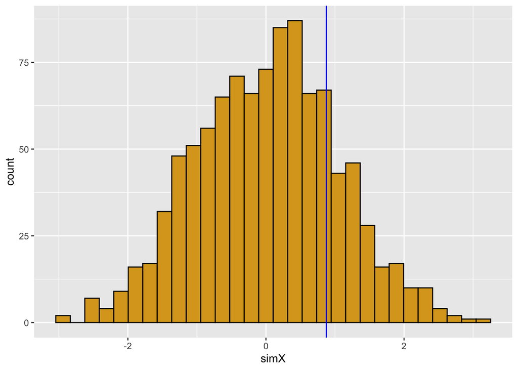

```r
# Create Histogram ------------------------------

##################################################
# function: plotRanTest
# create ggplot of histogram of simulated values
# input: list of observed metric and vector of simulated metrics
# output: saved ggplot graph
#-------------------------------------------------
plotRanTest <- function(z=NULL) {
                if(is.null(z)){
                  z <- list(rnorm(1),rnorm(1000)) }
dF <- data.frame(ID=seq_along(z[[2]]),simX=z[[2]])
p1 <- ggplot(data=dF,mapping=aes(x=simX))
p1 + geom_histogram(mapping=aes(fill=I("goldenrod"),color=I("black"))) +
geom_vline(aes(xintercept=z[[1]],col="blue"))

} # end of plotRanTest
#---------------------------------------------
plotRanTest()
```

```r
# Functions Work------------------------------

n_sim <- 1000 # number of simulated data sets
x_sim <- rep(NA,n_sim) # set up empty vector for simulated slopes
df <- readData() # get fake data
x_obs <- getMetric(df) # get slope of observed data

for (i in seq_len(n_sim)) {
  x_sim[i] <- getMetric(shuffleData(df))
}

slopes <- list(x_obs,x_sim)
getPVal(slopes)
```

```
##    pL    pU
## 0.989 0.011
```

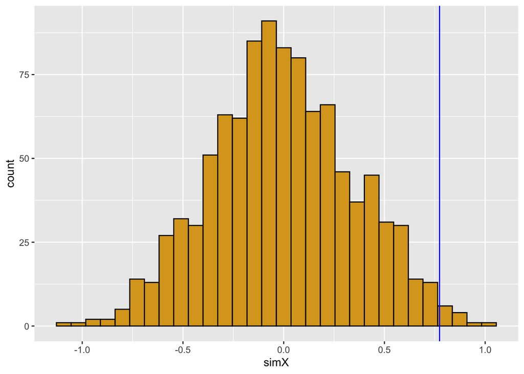

```r
plotRanTest(slopes)
```

5. For comparison, calculate in R the standard statistical analysis you would use with these data. How does the p-value compare for the standard test versus the p value you estimated from your randomization test? If there are persistent differences in the p value of the standard test versus your randomization, what do you think is responsible for this difference?

```r
# Fake Data Set

boatPres <- 1:20
freqMod <- boatPres + 10*rnorm(20)
z <- data.frame(ID=seq_along(boatPres),
                boatPres,
                freqMod)

# Regression analysis
reg_model <- lm(freqMod~boatPres, data=z)

# summary
summary(reg_model)
```

```
##
## Call:
## lm(formula = freqMod ~ boatPres, data = z)
##
## Residuals:
##     Min      1Q  Median      3Q     Max
## -11.171  -5.402  -1.132   5.262  13.861
##
## Coefficients:
##             Estimate Std. Error t value Pr(>|t|)
## (Intercept)  -5.5081     3.3240  -1.657 0.114830
## boatPres      1.2856     0.2775   4.633 0.000207 ***
## ---
## Signif. codes:  0 '***' 0.001 '**' 0.01 '*' 0.05 '.' 0.1 ' ' 1
##
## Residual standard error: 7.156 on 18 degrees of freedom
## Multiple R-squared:  0.5439, Adjusted R-squared:  0.5186
## F-statistic: 21.46 on 1 and 18 DF,  p-value: 0.0002067
```

```r
z <- unlist(summary(reg_model))

reg_stats <- list(intercept=z$coefficients1,
                  slope=z$coefficients2,
                  intercept_p=z$coefficients7,
                  slope_p=z$coefficients8,
                  r2=z$r.squared)
print(reg_stats)
```

```
## $intercept
## [1] -5.508097
##
## $slope
## [1] 1.285573
##
## $intercept_p
## [1] 0.1148302
##
## $slope_p
## [1] 0.0002066933
##
## $r2
## [1] 0.5438983
```

Running the linear regression resulted in a p-value of 0.0002 which is significant and the randomization test resulted in a p-value of 0.011 which is also significant. This makes sense because the research variables I used have shown significant results previously.